# Web scraping with R

Lise Vaudor / Sébastien Rey-Coyrehourcq / Fabien Pfaender

# Today !

- Webscraping, what is this ?
- Some ethicals considerations
- A theoritical HTML page
  - Read Html using rvest
  - How manipulate data efficiently (purrr, string)
  - How-to extract link & data from HTML (Regex, CSS, XPath)
- A cat and mouse game :)
- Tutorial & Uses cases

# Webscraping

- definition
- some elements of web architecture

# Ethics, some elements of reflexion.

**In two words**

- Grey Zone !! Heavily dependent of your country and the site you scrap !
- Law is clearly not so clear, but now RGPD include **derogations** for researchers
- Contact CNIL (France) or [similar institute in your country](https://www.cnil.fr/fr/la-protection-des-donnees-dans-le-monde), they will help you !
- **Don’t publish any data on the web** before anonymisation !
- Collect data limited to your project
- Protect personnal data very seriously (data-center, encrypted, firewall protection, etc.)

**In more than two words …**

- Read new European Law : GPDR or RGPD (not a joke, not so hard to read)
- Read this starting paper writed on this subject for this school : https://hackmd.io/g9JrWURjTHyLr9EWQqKoiQ?both
- Be inspirated by [existing case of scrapping](https://www.legifrance.gouv.fr/affichCnil.do?id=CNILTEXT000036945250) or other discipline (medecine)

# Packages

- `rvest`: web scraping
- `dplyr`: table-wrangling
- `stringr`: strings
- `purrr`: iteration

# A theoretical example of Web scraping

[figure not shown]

[figure not shown]

**HTML Document**

Understanding html documents’ structure

Tools **SelectorGadget** or html inspector

Package **rvest**:

To **collect the contents of a web page**, one has to:

- **read an html page** in R
- **get the element of interest** in the page (basic html, [SelectorGadget](https://cran.r-project.org/web/packages/rvest/vignettes/selectorgadget.html))
- **parse** the page
- **select an element** of the page
- **get the contents** of the element

# html tags

```
<html>
<style>
h1 {background-color: powderblue;}
.image {margin-left:50%;}
.comment{border-style:solid; background-color:LemonChiffon;}
.comment-author{font-style: italic;}
</style>
<h1> MA VIE A LA FERME </h1>
<div class="ingredients">
  <b> INGREDIENTS</b>
  <ul>
    <li> >1 cochon(s) </li>
    <li> >1 légume(s) </li>
  </ul>
</div>
<div class="right"><div class="image"><img src='images/cochon.png'></div></div>
<p> Je fais de la bouillie pour mes petits cochons.</p>
<p> Pour un cochon, pour deux cochons, pour trois cochons, pour quatre, puis pour cinq, pour six, pour sept, pour huit, pour neuf, boeuf! </p>
<b>comments</b>
<div class="comment">Et pour une poule sur un mur qui picoterait du pain dur?
</div>
<div class="comment-author">Emma, 22 ans, Limoges</div>
<div class="comment">Je vois que vous êtes, telle la petite poule rousse, bien aimable. Avez-vous pu compter sur l'aide du chat et du canard pour semer vos 5 grains de blé?</div>
<div class="comment-author">Michel, 56 ans, Rennes</div>
</html>
```

[interactive chart not shown]

# Read an html page

```
<html>
<style>
h1 {background-color: powderblue;}
.image {margin-left:50%;}
.comment{border-style:solid; background-color:LemonChiffon;}
.comment-author{font-style: italic;}
</style>
<h1> MA VIE A LA FERME </h1>
<div class="ingredients">
  <b> INGREDIENTS</b>
  <ul>
    <li> >1 cochon(s) </li>
    <li> >1 légume(s) </li>
  </ul>
</div>
<div class="right"><div class="image"><img src='images/cochon.png'></div></div>
<p> Je fais de la bouillie pour mes petits cochons.</p>
<p> Pour un cochon, pour deux cochons, pour trois cochons, pour quatre, puis pour cinq, pour six, pour sept, pour huit, pour neuf, boeuf! </p>
<b>comments</b>
<div class="comment">Et pour une poule sur un mur qui picoterait du pain dur?
</div>
<div class="comment-author">Emma, 22 ans, Limoges</div>
<div class="comment">Je vois que vous êtes, telle la petite poule rousse, bien aimable. Avez-vous pu compter sur l'aide du chat et du canard pour semer vos 5 grains de blé?</div>
<div class="comment-author">Michel, 56 ans, Rennes</div>
</html>
```

Read html page in R:

```r
library(rvest)
html=read_html("data/blog_de_ginette.htm", encoding="UTF-8")
html
```

```
## {xml_document}
## <html>
## [1] <head>\n<meta http-equiv="Content-Type" content="text/html; charset= ...
## [2] <body>\n<h1> MA VIE A LA FERME </h1>\n<div class="ingredients">\n  < ...
```

# Extract some elements in the html page

```
<html>
<style>
h1 {background-color: powderblue;}
.image {margin-left:50%;}
.comment{border-style:solid; background-color:LemonChiffon;}
.comment-author{font-style: italic;}
</style>
<h1> MA VIE A LA FERME </h1>
<div class="ingredients">
  <b> INGREDIENTS</b>
  <ul>
    <li> >1 cochon(s) </li>
    <li> >1 légume(s) </li>
  </ul>
</div>
<div class="right"><div class="image"><img src='images/cochon.png'></div></div>
<p> Je fais de la bouillie pour mes petits cochons.</p>
<p> Pour un cochon, pour deux cochons, pour trois cochons, pour quatre, puis pour cinq, pour six, pour sept, pour huit, pour neuf, boeuf! </p>
<b>comments</b>
<div class="comment">Et pour une poule sur un mur qui picoterait du pain dur?
</div>
<div class="comment-author">Emma, 22 ans, Limoges</div>
<div class="comment">Je vois que vous êtes, telle la petite poule rousse, bien aimable. Avez-vous pu compter sur l'aide du chat et du canard pour semer vos 5 grains de blé?</div>
<div class="comment-author">Michel, 56 ans, Rennes</div>
</html>
```

**Extract** some elements (“nodes” or “nodesets”):

```r
html_nodes(html,"b")
```

```
## {xml_nodeset (2)}
## [1] <b> INGREDIENTS</b>
## [2] <b>Commentaires</b>
```

```r
html_nodes(html,".comment-author")
```

```
## {xml_nodeset (2)}
## [1] <div class="comment-author">Emma, 22 ans, Limoges</div>
## [2] <div class="comment-author">Michel, 56 ans, Rennes</div>
```

```r
html_nodes(html,".ingredients") %>%
  html_children()
```

```
## {xml_nodeset (2)}
## [1] <b> INGREDIENTS</b>
## [2] <ul>\n<li> &gt;1 cochon(s) </li>\n    <li> &gt;1 légume(s) </li>\n   ...
```

# Extract the type of some elements

```
<html>
<style>
h1 {background-color: powderblue;}
.image {margin-left:50%;}
.comment{border-style:solid; background-color:LemonChiffon;}
.comment-author{font-style: italic;}
</style>
<h1> MA VIE A LA FERME </h1>
<div class="ingredients">
  <b> INGREDIENTS</b>
  <ul>
    <li> >1 cochon(s) </li>
    <li> >1 légume(s) </li>
  </ul>
</div>
<div class="right"><div class="image"><img src='images/cochon.png'></div></div>
<p> Je fais de la bouillie pour mes petits cochons.</p>
<p> Pour un cochon, pour deux cochons, pour trois cochons, pour quatre, puis pour cinq, pour six, pour sept, pour huit, pour neuf, boeuf! </p>
<b>comments</b>
<div class="comment">Et pour une poule sur un mur qui picoterait du pain dur?
</div>
<div class="comment-author">Emma, 22 ans, Limoges</div>
<div class="comment">Je vois que vous êtes, telle la petite poule rousse, bien aimable. Avez-vous pu compter sur l'aide du chat et du canard pour semer vos 5 grains de blé?</div>
<div class="comment-author">Michel, 56 ans, Rennes</div>
</html>
```

**Extract the type** of nodes or nodesets:

```r
html_nodes(html,".image") %>%
  html_name()
```

```
## [1] "div"
```

# Extract the content of some elements

```
<html>
<style>
h1 {background-color: powderblue;}
.image {margin-left:50%;}
.comment{border-style:solid; background-color:LemonChiffon;}
.comment-author{font-style: italic;}
</style>
<h1> MA VIE A LA FERME </h1>
<div class="ingredients">
  <b> INGREDIENTS</b>
  <ul>
    <li> >1 cochon(s) </li>
    <li> >1 légume(s) </li>
  </ul>
</div>
<div class="right"><div class="image"><img src='images/cochon.png'></div></div>
<p> Je fais de la bouillie pour mes petits cochons.</p>
<p> Pour un cochon, pour deux cochons, pour trois cochons, pour quatre, puis pour cinq, pour six, pour sept, pour huit, pour neuf, boeuf! </p>
<b>comments</b>
<div class="comment">Et pour une poule sur un mur qui picoterait du pain dur?
</div>
<div class="comment-author">Emma, 22 ans, Limoges</div>
<div class="comment">Je vois que vous êtes, telle la petite poule rousse, bien aimable. Avez-vous pu compter sur l'aide du chat et du canard pour semer vos 5 grains de blé?</div>
<div class="comment-author">Michel, 56 ans, Rennes</div>
</html>
```

**Extract the content** of nodes or nodesets:

```r
html_nodes(html,"b") %>%
  html_text()
```

```
## [1] " INGREDIENTS" "Commentaires"
```

# Extract the attributes of some elements

```
<html>
<style>
h1 {background-color: powderblue;}
.image {margin-left:50%;}
.comment{border-style:solid; background-color:LemonChiffon;}
.comment-author{font-style: italic;}
</style>
<h1> MA VIE A LA FERME </h1>
<div class="ingredients">
  <b> INGREDIENTS</b>
  <ul>
    <li> >1 cochon(s) </li>
    <li> >1 légume(s) </li>
  </ul>
</div>
<div class="right"><div class="image"><img src='images/cochon.png'></div></div>
<p> Je fais de la bouillie pour mes petits cochons.</p>
<p> Pour un cochon, pour deux cochons, pour trois cochons, pour quatre, puis pour cinq, pour six, pour sept, pour huit, pour neuf, boeuf! </p>
<b>comments</b>
<div class="comment">Et pour une poule sur un mur qui picoterait du pain dur?
</div>
<div class="comment-author">Emma, 22 ans, Limoges</div>
<div class="comment">Je vois que vous êtes, telle la petite poule rousse, bien aimable. Avez-vous pu compter sur l'aide du chat et du canard pour semer vos 5 grains de blé?</div>
<div class="comment-author">Michel, 56 ans, Rennes</div>
</html>
```

**Extract the attributes** of nodes or nodesets:

```r
html_nodes(html,"div") %>%
  html_attrs()
```

```
## [[1]]
##         class
## "ingredients"
##
## [[2]]
##   class
## "right"
##
## [[3]]
##   class
## "image"
##
## [[4]]
##     class
## "comment"
##
## [[5]]
##            class
## "comment-author"
##
## [[6]]
##     class
## "comment"
##
## [[7]]
##            class
## "comment-author"
```

# Rectangular format, and function-ization

[figure not shown]

Extract data and make it into a table:

```r
page="data/blog_de_ginette.htm"
html=read_html(page, encoding="UTF-8")
texte=html %>% html_nodes(".comment") %>% html_text()
auteur=html %>% html_nodes(".comment-author") %>% html_text()
tib_comments=tibble(texte,auteur)
tib_comments
```

```
## # A tibble: 2 x 2
##   texte                                                         auteur
##   <chr>                                                         <chr>
## 1 Et pour une poule sur un mur qui picoterait du pain dur? c'e… Emma, 22 …
## 2 Je vois que vous êtes, telle la petite poule rousse, bien ai… Michel, 5…
```

It is actually a good idea to make all this into a fonction that would have the page’s url as intput and the tibble as output:

```r
extract_comments=function(page){
  html=read_html(page, encoding="UTF-8")
  texte=html %>% html_nodes(".comment") %>% html_text()
  auteur=html %>% html_nodes(".comment-author") %>% html_text()
  tib_comments=tibble(doc=rep(page,length(texte)),
                          texte,
                          auteur)
  return(tib_comments)
}

extract_comments("data/blog_de_ginette.htm")
```

```
## # A tibble: 2 x 3
##   doc                      texte                                  auteur
##   <chr>                    <chr>                                  <chr>
## 1 data/blog_de_ginette.htm Et pour une poule sur un mur qui pico… Emma, 2…
## 2 data/blog_de_ginette.htm Je vois que vous êtes, telle la petit… Michel,…
```

```r
extract_comments("data/blog_de_jean-marc.htm")
```

```
## # A tibble: 6 x 3
##   doc                        texte                            auteur
##   <chr>                      <chr>                            <chr>
## 1 data/blog_de_jean-marc.htm Les thons, avec un t comme croc… "Eddie, 76 …
## 2 data/blog_de_jean-marc.htm Pourquoi ces thons ne préféraie… Yves, 40 an…
## 3 data/blog_de_jean-marc.htm Tout ça me fait penser au blog … Roberta, 18…
## 4 data/blog_de_jean-marc.htm Je préfère la chanson qui parle… Eduardo, 29…
## 5 data/blog_de_jean-marc.htm On ne comprend pas trop cette p… Lise, 35 an…
## 6 data/blog_de_jean-marc.htm Et pendant ce temps-là, le roi … Nadia, 43 a…
```

# Iteration

[figure not shown]

Now, let’s imagine that we actually have to deal with several pages **with a common structure**.

We would like to apply `extract_comments()` iteratively to all these pages.

The `purrr` package enables us to **apply a function iteratively** to all elements of a list or of a vector (… of course this is just a more straightforward way to loop through a `for` structure…).

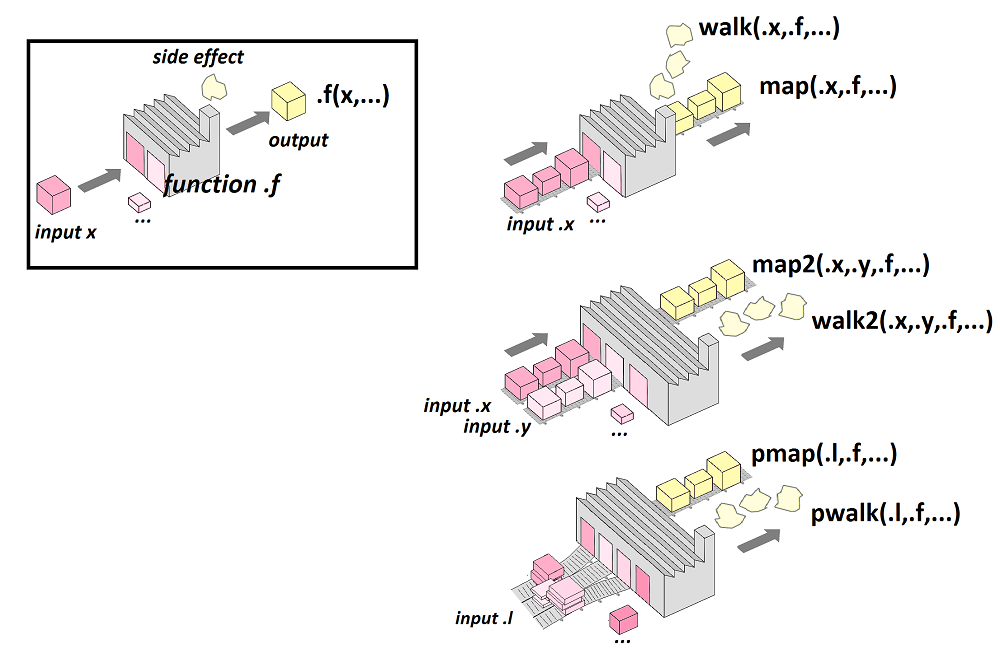

# Iteration with purrr

```r
pages=c("data/blog_de_ginette.htm",
        "data/blog_de_jean-marc.htm",
        "data/blog_de_norbert.htm")

list_comments=map(pages, extract_comments)
list_comments
```

```
## [[1]]
## # A tibble: 2 x 3
##   doc                      texte                                  auteur
##   <chr>                    <chr>                                  <chr>
## 1 data/blog_de_ginette.htm Et pour une poule sur un mur qui pico… Emma, 2…
## 2 data/blog_de_ginette.htm Je vois que vous êtes, telle la petit… Michel,…
##
## [[2]]
## # A tibble: 6 x 3
##   doc                        texte                            auteur
##   <chr>                      <chr>                            <chr>
## 1 data/blog_de_jean-marc.htm Les thons, avec un t comme croc… "Eddie, 76 …
## 2 data/blog_de_jean-marc.htm Pourquoi ces thons ne préféraie… Yves, 40 an…
## 3 data/blog_de_jean-marc.htm Tout ça me fait penser au blog … Roberta, 18…
## 4 data/blog_de_jean-marc.htm Je préfère la chanson qui parle… Eduardo, 29…
## 5 data/blog_de_jean-marc.htm On ne comprend pas trop cette p… Lise, 35 an…
## 6 data/blog_de_jean-marc.htm Et pendant ce temps-là, le roi … Nadia, 43 a…
##
## [[3]]
## # A tibble: 4 x 3
##   doc                      texte                          auteur
##   <chr>                    <chr>                          <chr>
## 1 data/blog_de_norbert.htm "A quel moment faut-il claque… Jonas, 37 ans, …
## 2 data/blog_de_norbert.htm Norbert, mon petit chat, ça f… Julie, 34 ans, …
## 3 data/blog_de_norbert.htm L'ambiance doit être sympa qu… Mickaël, 23 ans…
## 4 data/blog_de_norbert.htm Vous devez avoir un grain pou… Viviane, 58 ans…
```

```r
tibtot_comments <- list_comments %>%
  bind_rows()
tibtot_comments
```

```
## # A tibble: 12 x 3
##    doc                        texte                             auteur
##    <chr>                      <chr>                             <chr>
##  1 data/blog_de_ginette.htm   Et pour une poule sur un mur qui… Emma, 22 …
##  2 data/blog_de_ginette.htm   Je vois que vous êtes, telle la … Michel, 5…
##  3 data/blog_de_jean-marc.htm Les thons, avec un t comme croco… "Eddie, 7…
##  4 data/blog_de_jean-marc.htm Pourquoi ces thons ne préféraien… Yves, 40 …
##  5 data/blog_de_jean-marc.htm Tout ça me fait penser au blog d… Roberta, …
##  6 data/blog_de_jean-marc.htm Je préfère la chanson qui parle … Eduardo, …
##  7 data/blog_de_jean-marc.htm On ne comprend pas trop cette pa… Lise, 35 …
##  8 data/blog_de_jean-marc.htm Et pendant ce temps-là, le roi d… Nadia, 43…
##  9 data/blog_de_norbert.htm   "A quel moment faut-il claquer d… Jonas, 37…
## 10 data/blog_de_norbert.htm   Norbert, mon petit chat, ça fait… Julie, 34…
## 11 data/blog_de_norbert.htm   L'ambiance doit être sympa quand… Mickaël, …
## 12 data/blog_de_norbert.htm   Vous devez avoir un grain pour é… Viviane, …
```

# Manipulate strings: package stringr

Package **stringr** Blog post (in French) [here](http://perso.ens-lyon.fr/lise.vaudor/manipuler-des-strings-avec-r/).

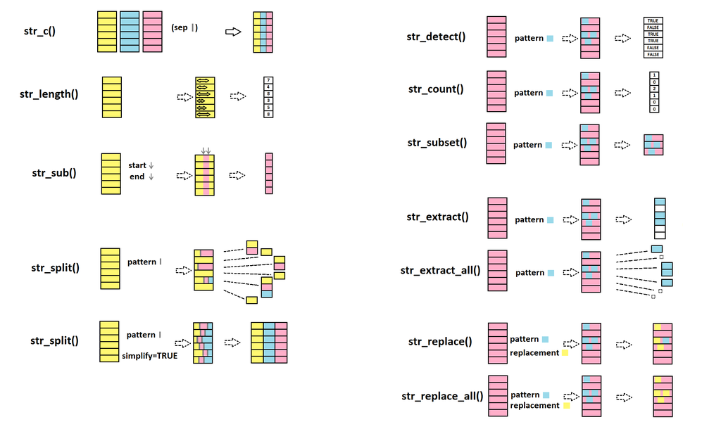

# Strings: concatenate, replace pattern

**str_c()** to combine strings

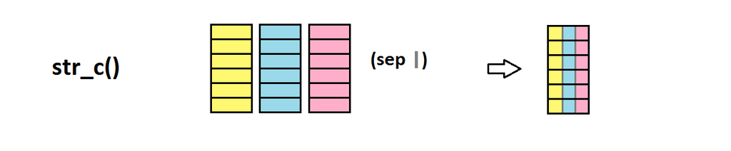

```r
str_c("abra","ca","dabra")
```

```
## [1] "abracadabra"
```

```r
str_c("Les jeux","de mots laids","sont pour","les gens bêtes", sep=" ")
```

```
## [1] "Les jeux de mots laids sont pour les gens bêtes"
```

**str_detect()** detects a pattern

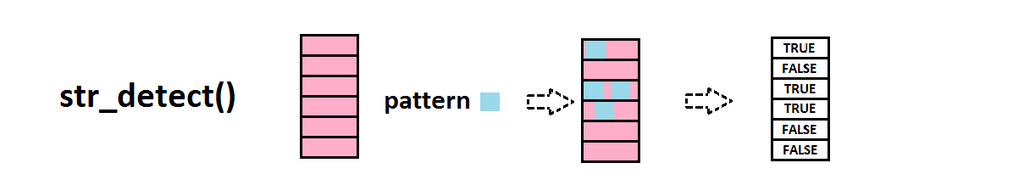

```r
str_detect(c("Quarante","carottes","crues",
             "croient","que","croquer",
             "crée","des","crampes."),
           pattern="cr")
```

```
## [1] FALSE FALSE  TRUE  TRUE FALSE  TRUE  TRUE FALSE  TRUE
```

# Strings: replace pattern, extract pattern

**str_replace()** replaces a pattern with another

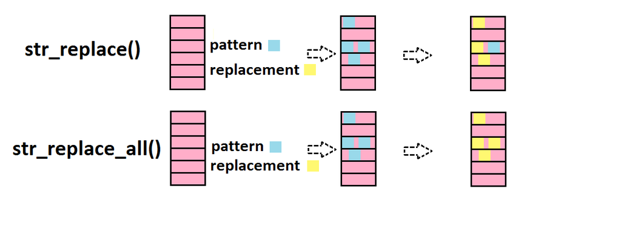

```r
str_replace(c("All we hear is",
              "Radio ga ga",
              "Radio goo goo",
              "Radio ga ga"),
            pattern="goo",
            replacement="ga")
```

```
## [1] "All we hear is" "Radio ga ga"    "Radio ga goo"   "Radio ga ga"
```

**str_extract()** extracts the pattern (if it’s there!)

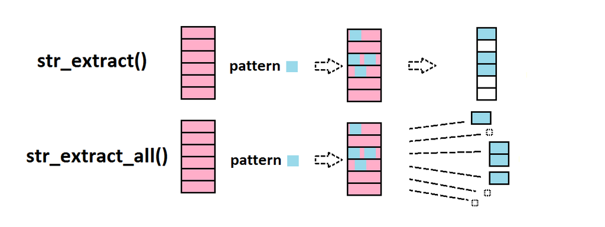

```r
str_extract(c("L'âne","Trotro","trotte","à une allure","traitreusement","tranquille"),
           pattern="tr")
```

```
## [1] NA   "tr" "tr" NA   "tr" "tr"
```

# Regular expressions

**Regular expressions** are used to define **patterns** through **rules of construction**.[A tutorial here](http://stringr.tidyverse.org/articles/regular-expressions.html)

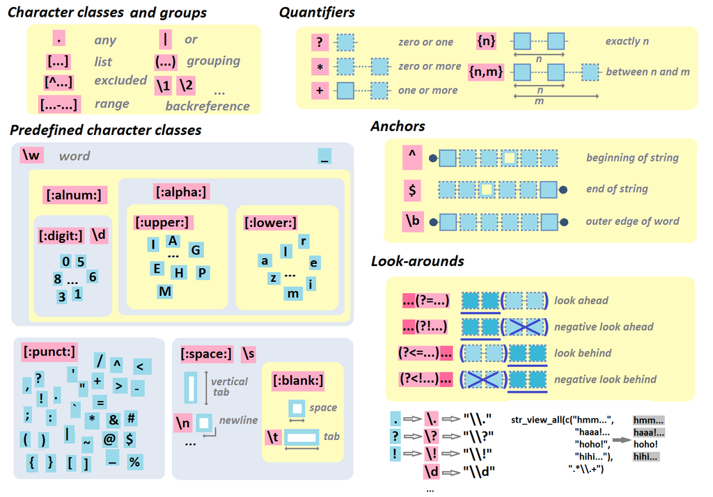

.

# Regexp: character classes and groups

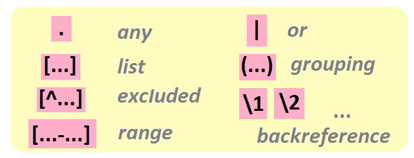

A **character class** corresponds to the notation `[...]`.

For instance, to detect all voyels in the string:

```r
str_view_all("youp la boum",
             "[aeiou]")
```

[interactive chart not shown]

See the difference:

```r
str_view_all("A132-f445-e34-C308-M9-E18",
             "[308]")
```

[interactive chart not shown]

```r
str_view_all("A132-f445-e34-C308-M9-E18",
             "308")
```

[interactive chart not shown]

**Any character** can be noted `.`.

For instance, the pattern “any character followed by a letter” can be searched through

```r
str_view_all("32a-B44-552-98eEf",
             ".[a-z]")
```

[interactive chart not shown]

# Regexp: special characters

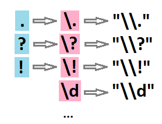

To find dots, question marks, exclamation marks:

```r
str_view_all(c("Allô, John-John? Ici Joe la frite. Surprise!"),
             "[\\.\\?\\!]")
```

[interactive chart not shown]

Note that we don’t write `"[.?!]"`, but `"[\\.\\?\\!]"`.

`.` (as we saw before), as well as `?` and `!` are **special characters**. So, to point out *actual* dots or interrogation/exclamation marks, one has to use the escape character `\`. The regular expression hence becomes `[\.\?\!]`…

But it does not end here… as it is not *directly* the regular expression that is passed to the function, but a *string* that is *interpreted as a regular expression*. Thus each escape character `\` has to be escaped through a `\`. So that the pattern passed to the function is actually `"[\\.\\?\\!]"`.

# Regexp: excluded characters, character ranges

A character class can be defined as all characters **excluding the ones listed**. This is noted as `[^...]`:

For instance, all characters that are neither a vowel nor a blank space:

```r
str_view_all("turlututu chapeau pointu",
             "[^aeiou ]")
```

[interactive chart not shown]

Ranges of characters are noted `[...-...]`

For instance, all numbers between 1 and 5:

```r
str_view_all(c("3 petits cochons", "101 dalmations", "7 nains"),
             "[1-5]")
```

[interactive chart not shown]

… or all those between A-F or a-e:

```r
str_view_all("A132-f445-e34-C308-M2244-Z449-E18",
             "[A-Fa-e]")
```

[interactive chart not shown]

# Regexp: predefined classes

Some character classes are predefined for instance **digits**, **punctuation characters**, **lower-case alphabetical characters**, etc.

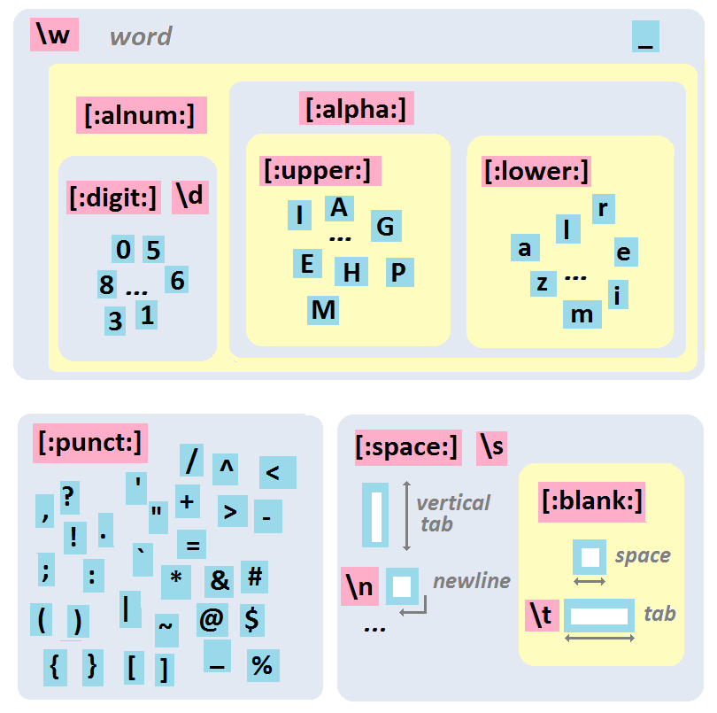

# Regexp: quantifiers

Quantifiers are used to specify **how many consecutive times** a particular class or group occurs.

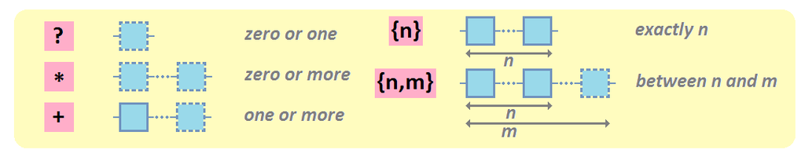

**zero or one**: the pattern of interest is followed by `?`.

```r
str_view_all(c("file1990-fileB1990-fileAbis2005"),
             "file\\d?")
```

[interactive chart not shown]

**zero or more**: O the pattern of interest is followed by `*`.

```r
str_view_all(c("file1990-fileB1990-fileAbis2005"),
             "file\\d*")
```

[interactive chart not shown]

**one or more** : the pattern of interest is followed by `+`.

```r
str_view_all(c("file1990-fileB1990-fileAbis2005"),
             "file\\d+")
```

[interactive chart not shown]